# Cellphone Billing Project

## Model estimations for duration models

1. Plot the Kaplan-Meier survival function estimates for each plan choice on the same graph

```r
#install.packages("survival")
library(survival)
```

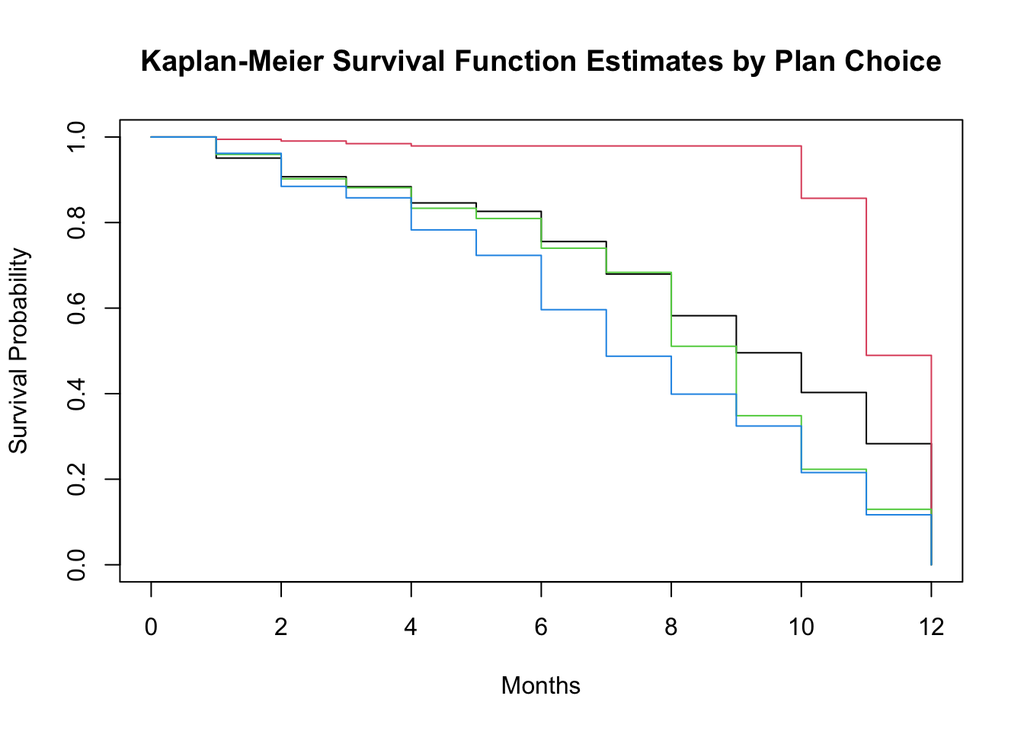

```r
# Create a Surv object for survival analysis
surv_obj <- Surv(time = merged_data$bill_month, event = merged_data$churn)

# Compute the Kaplan-Meier survival function estimates for each plan choice
km_estimates <- survfit(surv_obj ~ merged_data$plan_chosen)

# Plot the Kaplan-Meier survival function estimates for each plan choice on the same graph
plot(km_estimates, col = 1:4, xlab = "Months", ylab = "Survival Probability", main = "Kaplan-Meier Survival Function Estimates by Plan Choice")
```

2. Estimate the Cox proportional hazard (PH) type duration data models using a semi-parametric approach.

```r
# Estimate the Cox PH model
cox_ph_model <- coxph(surv_obj ~ plan_chosen + ave_minute_peak + promo_pct + age + newcell + ruca2 + zip_comm, data = merged_data)

# Display the results
summary(cox_ph_model)
```

```
## Call:
## coxph(formula = surv_obj ~ plan_chosen + ave_minute_peak + promo_pct +
##     age + newcell + ruca2 + zip_comm, data = merged_data)
##
##   n= 12319, number of events= 4848
##    (176 observations deleted due to missingness)
##
##                       coef  exp(coef)   se(coef)      z Pr(>|z|)
## plan_chosen      0.1120465  1.1185649  0.0156654  7.152 8.52e-13 ***
## ave_minute_peak  0.0002078  1.0002079  0.0001454  1.429  0.15290
## promo_pct        0.1226752  1.1305172  0.0593211  2.068  0.03864 *
## age             -0.0109161  0.9891432  0.0010917 -9.999  < 2e-16 ***
## newcell         -0.1348020  0.8738889  0.0488949 -2.757  0.00583 **
## ruca2            0.0275484  1.0279314  0.0089252  3.087  0.00202 **
## zip_comm         0.2008662  1.2224612  0.0998352  2.012  0.04422 *
## ---
## Signif. codes:  0 '***' 0.001 '**' 0.01 '*' 0.05 '.' 0.1 ' ' 1
##
##                 exp(coef) exp(-coef) lower .95 upper .95
## plan_chosen        1.1186     0.8940    1.0847    1.1534
## ave_minute_peak    1.0002     0.9998    0.9999    1.0005
## promo_pct          1.1305     0.8846    1.0064    1.2699
## age                0.9891     1.0110    0.9870    0.9913
## newcell            0.8739     1.1443    0.7940    0.9618
## ruca2              1.0279     0.9728    1.0101    1.0461
## zip_comm           1.2225     0.8180    1.0052    1.4867
##
## Concordance= 0.585  (se = 0.006 )
## Likelihood ratio test= 278.9  on 7 df,   p=<2e-16
## Wald test            = 272.8  on 7 df,   p=<2e-16
## Score (logrank) test = 274.5  on 7 df,   p=<2e-16
```

```r
# Compute the AIC for the Cox PH model
cox_ph_aic <- AIC(cox_ph_model)
```

```r
cox_ph_aic
```

```
## [1] 77001.51
```

3. Estimate the accelerated failure time (AFT) type duration data models using the exponential and Weibull distributions.

```r
# Estimate the AFT model with the exponential distribution
aft_exp_model <- survreg(surv_obj ~ plan_chosen + ave_minute_peak + promo_pct + age + newcell + ruca2 + zip_comm, data = merged_data, dist = "exponential")

# Display the results
summary(aft_exp_model)
```

```
##
## Call:
## survreg(formula = surv_obj ~ plan_chosen + ave_minute_peak +
##     promo_pct + age + newcell + ruca2 + zip_comm, data = merged_data,
##     dist = "exponential")
##                     Value Std. Error     z       p
## (Intercept)      2.207795   0.075942 29.07 < 2e-16
## plan_chosen     -0.048248   0.015889 -3.04  0.0024
## ave_minute_peak -0.000925   0.000143 -6.45 1.1e-10
## promo_pct       -0.025705   0.059485 -0.43  0.6656
## age              0.013740   0.001094 12.56 < 2e-16
## newcell          0.416840   0.048551  8.59 < 2e-16
## ruca2           -0.043480   0.008944 -4.86 1.2e-06
## zip_comm        -0.185351   0.099721 -1.86  0.0631
##
## Scale fixed at 1
##
## Exponential distribution
## Loglik(model)= -17481.8   Loglik(intercept only)= -17725.5
##  Chisq= 487.45 on 7 degrees of freedom, p= 4e-101
## Number of Newton-Raphson Iterations: 5
## n=12319 (176 observations deleted due to missingness)
```

```r
# Compute the AIC for the AFT model with the exponential distribution
aft_exp_aic <- AIC(aft_exp_model)

# Estimate the AFT model with the Weibull distribution
aft_weibull_model <- survreg(surv_obj ~ plan_chosen + ave_minute_peak + promo_pct + age + newcell + ruca2 + zip_comm, data = merged_data, dist = "weibull")

# Display the results
summary(aft_weibull_model)
```

```
##
## Call:
## survreg(formula = surv_obj ~ plan_chosen + ave_minute_peak +
##     promo_pct + age + newcell + ruca2 + zip_comm, data = merged_data,
##     dist = "weibull")
##                     Value Std. Error      z       p
## (Intercept)      2.11e+00   3.20e-02  65.95 < 2e-16
## plan_chosen     -2.94e-02   6.63e-03  -4.43 9.3e-06
## ave_minute_peak -1.77e-04   6.17e-05  -2.86 0.00426
## promo_pct       -3.16e-02   2.50e-02  -1.26 0.20645
## age              4.45e-03   4.66e-04   9.54 < 2e-16
## newcell          9.20e-02   2.07e-02   4.45 8.6e-06
## ruca2           -1.41e-02   3.78e-03  -3.74 0.00018
## zip_comm        -8.56e-02   4.21e-02  -2.03 0.04218
## Log(scale)      -8.62e-01   1.07e-02 -80.75 < 2e-16
##
## Scale= 0.422
##
## Weibull distribution
## Loglik(model)= -15403   Loglik(intercept only)= -15528
##  Chisq= 249.94 on 7 degrees of freedom, p= 2.9e-50
## Number of Newton-Raphson Iterations: 6
## n=12319 (176 observations deleted due to missingness)
```

```r
# Compute the AIC for the AFT model with the Weibull distribution
aft_weibull_aic <- AIC(aft_weibull_model)
```

```r
aft_weibull_aic
```

```
## [1] 30823.97
```

4. Evaluate the estimated model fit and performance using the AIC measure.

```r
# Compare the AIC values
cat("AIC values:\nCox PH model:", cox_ph_aic, "\nAFT Exponential model:", aft_exp_aic, "\nAFT Weibull model:", aft_weibull_aic, "\n")
```

```
## AIC values:
## Cox PH model: 77001.51
## AFT Exponential model: 34979.55
## AFT Weibull model: 30823.97
```

5. Interpret either the hazard ratio (for PH model) or time ratio (for AFT model) associated with plan2 to plan 4 dummies (relative to plan 1) and age on the probability of or time to churning.

```r
# Compute time ratios for the best model (AFT Weibull)
time_ratios <- exp(coef(aft_weibull_model))
time_ratios
```

```
##     (Intercept)     plan_chosen ave_minute_peak       promo_pct             age
##       8.2692361       0.9710389       0.9998235       0.9688519       1.0044574
##         newcell           ruca2        zip_comm
##       1.0964031       0.9859539       0.9179447
```

```r
# Compute 95% confidence intervals for time ratios
conf_ints <- confint(aft_weibull_model, level = 0.95)
ci_lower <- exp(conf_ints[, 1])
ci_upper <- exp(conf_ints[, 2])

# Combine time ratios and their confidence intervals
time_ratios_ci <- data.frame(TimeRatio = time_ratios, LowerCI = ci_lower, UpperCI = ci_upper)
time_ratios_ci
```

```
##                 TimeRatio   LowerCI   UpperCI
## (Intercept)     8.2692361 7.7660449 8.8050309
## plan_chosen     0.9710389 0.9585009 0.9837410
## ave_minute_peak 0.9998235 0.9997025 0.9999445
## promo_pct       0.9688519 0.9224392 1.0176000
## age             1.0044574 1.0035396 1.0053760
## newcell         1.0964031 1.0528486 1.1417594
## ruca2           0.9859539 0.9786799 0.9932821
## zip_comm        0.9179447 0.8451745 0.9969805
```

## Using random forest classifier to predict churn

```r
# Load the necessary library
library(randomForest)
merged_data_clean$churn <- as.factor(merged_data_clean$churn)

# Split the data into training and test sets
set.seed(123)
trainIndex <- sample(1:nrow(merged_data_clean), round(0.7 * nrow(merged_data_clean)), replace = FALSE)
trainData <- merged_data_clean[trainIndex, ]
testData <- merged_data_clean[-trainIndex, ]

# Train the model
rf_model <- randomForest(churn ~., data = trainData, importance = TRUE)

# Make predictions on the test set
rf_pred <- predict(rf_model, testData)

# Evaluate the model performance
rf_cm <- table(Predicted = rf_pred, Actual = testData$churn)
rf_accuracy <- sum(diag(rf_cm)) / sum(rf_cm)
print(paste0("Random Forest Classifier Accuracy: ", round(rf_accuracy * 100, 2), "%"))
```

```
## [1] "Random Forest Classifier Accuracy: 100%"
```

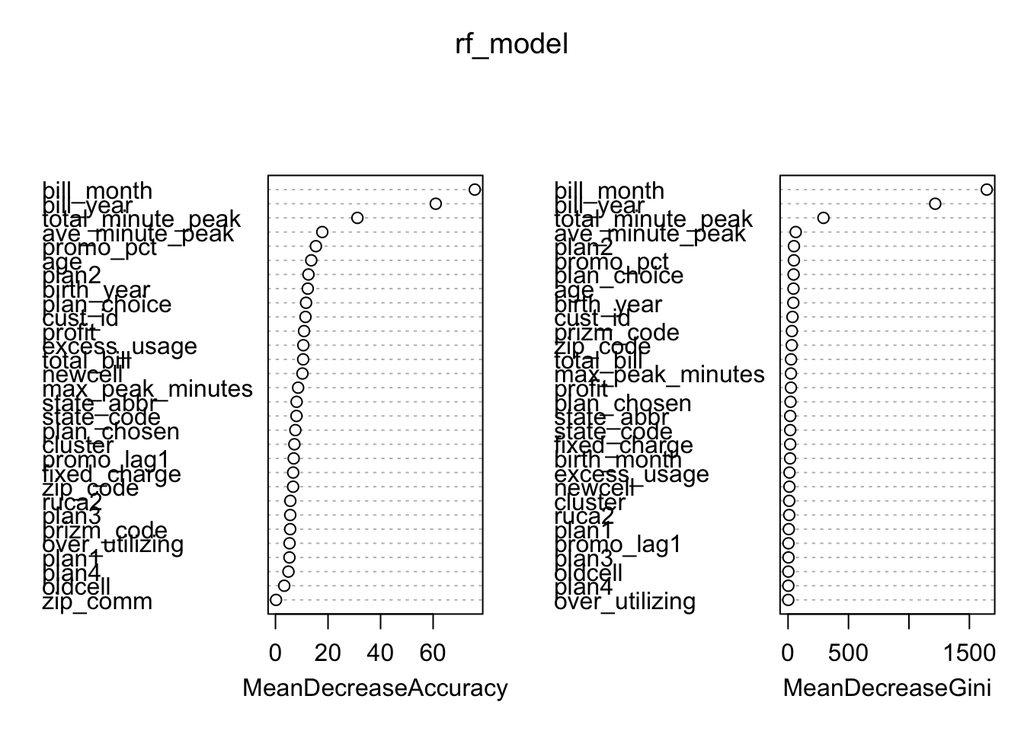

```r
# Plot variable importance
varImpPlot(rf_model)
```